# MVA Midterm Exam

pg606@scarletmail.rutgers.edu

2024-04-01

```r
library(psych)
library(readr)
## Warning: package 'readr' was built under R version 4.3.2
library(factoextra)
library(FactoMineR)
```

```r
## Warning: package 'FactoMineR' was built under R version 4.3.3
library(magrittr)
library(NbClust)
library(readr)
library(lattice)
library(ggplot2)
library(ggridges)
library(ggvis)
library(ggthemes)
library(cowplot)
library(gapminder)
library(gganimate)
library(dplyr)
library(tidyverse)
library(grid)
library(gridExtra)
library(RColorBrewer)
library(cluster)
library(readr)
library(factoextra)
library(magrittr)
library(NbClust)
library(ggplot2) # for visualization
library(reshape2) # for data manipulation
library(factoextra)
library(FactoMineR)
library(psych)
library(corrplot)
library(devtools)
```

# DATASET DESCRIPTION :

# DATA DICTIONARY:

```r
animal_data <- read.csv("/Users/Prateekg/Downloads/Animal_Rights.csv", row.names=1)
```

# About the dataset:

```r
summary(animal_data)
```

```
##  Recognition.of.Animal.Sentience Recognition.of.Animal.Suffering
##  Min.   :0.0000                  Min.   :0.0000
##  1st Qu.:0.0000                  1st Qu.:1.0000
##  Median :1.0000                  Median :1.0000
##  Mean   :0.7164                  Mean   :0.8955
##  3rd Qu.:1.0000                  3rd Qu.:1.0000
##  Max.   :2.0000                  Max.   :2.0000
##  Any.Laws.Against.Animal.Cruelty
##  Min.   :0.0000
##  1st Qu.:1.0000
##  Median :1.0000
##  Mean   :0.9701
##  3rd Qu.:1.0000
##  Max.   :2.0000
##  Support.for.the.Universal.Declaration.of.Animal.Welfare Fur.Farming.Ban
##  Min.   :0.0000                                          Min.   :0.0000
##  1st Qu.:0.0000                                          1st Qu.:0.0000
##  Median :1.0000                                          Median :1.0000
##  Mean   :0.9701                                          Mean   :0.8955
##  3rd Qu.:2.0000                                          3rd Qu.:2.0000
##  Max.   :2.0000                                          Max.   :2.0000
##  Meat.Consumption.per.Capita.in.Kilograms Percentage.of.Protected.Areas
##  Min.   :  3.78                           Min.   : 0.22
##  1st Qu.: 37.42                           1st Qu.:10.70
##  Median : 65.77                           Median :18.47
##  Mean   : 61.48                           Mean   :19.69
##  3rd Qu.: 81.36                           3rd Qu.:27.64
##  Max.   :124.10                           Max.   :54.14
##  Kgs.of.Pesticide...Hectare.of.Cropland Environmental.Performance.Index.Score
##  Min.   : 0.00006                       Min.   :25.10
##  1st Qu.: 0.80000                       1st Qu.:44.00
##  Median : 2.00000                       Median :57.00
##  Mean   : 3.19900                       Mean   :57.27
##  3rd Qu.: 4.80000                       3rd Qu.:71.15
##  Max.   :13.10000                       Max.   :82.50
##   Total.Score
##  Min.   : 12.46
##  1st Qu.:252.23
##  Median :359.53
##  Mean   :342.78
##  3rd Qu.:451.29
##  Max.   :519.68
```

-Recognition of Animal Sentience and Suffering: The dataset indicates that recognition scores for both animal sentience and suffering range from 0 to 2. The mean recognition of animal sentience is around 0.7164, while for animal suffering, it is approximately 0.8955. Most countries have recognition scores above 0, suggesting some level of acknowledgment for animal sentience and suffering.

-Laws Against Animal Cruelty: The dataset shows that the minimum and maximum values for laws against animal cruelty are 0 and 2, respectively, with a mean score of approximately 0.9701. This indicates that the majority of countries have some form of laws against animal cruelty.

-Meat Consumption per Capita: Meat consumption per capita ranges from approximately 3.78 to 124.10 kilograms, with a mean consumption of around 61.48 kilograms. This suggests significant meat consumption across the sampled countries.

-Percentage of Protected Areas: The percentage of protected areas varies from approximately 0.22% to 54.14%, with a mean percentage of approximately 19.69%. This indicates differing levels of environmental conservation efforts among the countries.

-Pesticide Usage: Pesticide usage per hectare of cropland ranges from approximately 0.00006 to 13.1 kilograms, with a mean usage of approximately 3.199 kilograms. This suggests varying agricultural practices among the countries.

-Environmental Performance Index (EPI) Score: The EPI score ranges from approximately 25.10 to 82.50, with a mean score of approximately 57.27. This indicates differences in environmental performance across the sampled countries.

-Total Score: The total score ranges from approximately 12.46 to 519.68, with a mean total score of approximately 342.78. This reflects variations in overall performance among the countries across the measured dimensions. Q- Visualize the countries across all the dimensions in one chart so you can easily see similar countries. # VISUALIZING THE COUNTRIES :

The stars chart is useful for visualization because it allows for the simultaneous comparison of multiple variables across different categories or groups.

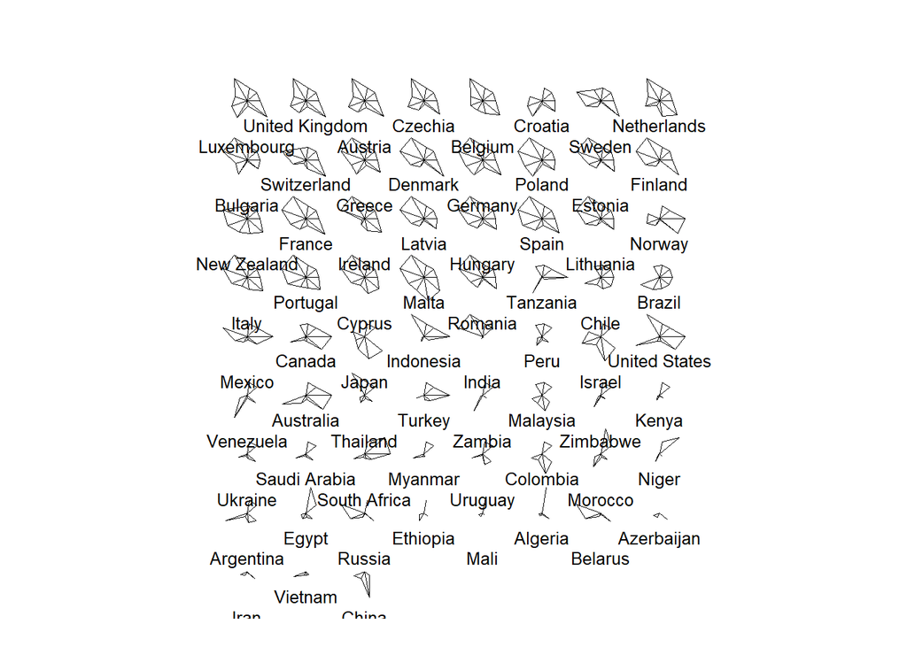

```r
animal <- animal_data[,-10]
stars(animal)
```

This code will create a stars chart using the animal dataset, where each country is represented by a star shape, and the dimensions are represented by the number of points on the star’s perimeter. Each point’s position on the perimeter indicates the value of that dimension for the respective country. This allows for a multivariate visualization of the data, making it easier to compare countries across multiple variables simultaneously and also to find similar countries through its patterns.

```r
#Get the Correlations between the measurements

correlation_matrix <- cor(animal_data[,1:9][-1])
correlation_matrix
```

```
##                                                         Recognition.of.Animal.Suffering
## Recognition.of.Animal.Suffering                                              1.00000000
## Any.Laws.Against.Animal.Cruelty                                              0.41983987
## Support.for.the.Universal.Declaration.of.Animal.Welfare                      0.27841294
## Fur.Farming.Ban                                                              0.09437972
## Meat.Consumption.per.Capita.in.Kilograms                                     0.10814868
## Percentage.of.Protected.Areas                                                0.23691549
## Kgs.of.Pesticide...Hectare.of.Cropland                                       0.08698954
## Environmental.Performance.Index.Score                                        0.22598771
##                                                         Any.Laws.Against.Animal.Cruelty
## Recognition.of.Animal.Suffering                                             0.419839872
## Any.Laws.Against.Animal.Cruelty                                             1.000000000
## Support.for.the.Universal.Declaration.of.Animal.Welfare                     0.090460664
## Fur.Farming.Ban                                                            -0.009885566
## Meat.Consumption.per.Capita.in.Kilograms                                   -0.109790706
## Percentage.of.Protected.Areas                                               0.156934813
## Kgs.of.Pesticide...Hectare.of.Cropland                                     -0.066465579
## Environmental.Performance.Index.Score                                       0.070490495
##                                                         Support.for.the.Universal.Declaration.of.Animal.Welfare
## Recognition.of.Animal.Suffering                                                                      0.27841294
## Any.Laws.Against.Animal.Cruelty                                                                      0.09046066
## Support.for.the.Universal.Declaration.of.Animal.Welfare                                              1.00000000
## Fur.Farming.Ban                                                                                      0.62683139
## Meat.Consumption.per.Capita.in.Kilograms                                                             0.31457623
## Percentage.of.Protected.Areas                                                                        0.31029058
## Kgs.of.Pesticide...Hectare.of.Cropland                                                               0.08066993
## Environmental.Performance.Index.Score                                                                0.56947319
##                                                         Fur.Farming.Ban
## Recognition.of.Animal.Suffering                             0.094379722
## Any.Laws.Against.Animal.Cruelty                            -0.009885566
## Support.for.the.Universal.Declaration.of.Animal.Welfare     0.626831392
## Fur.Farming.Ban                                             1.000000000
## Meat.Consumption.per.Capita.in.Kilograms                    0.397104442
## Percentage.of.Protected.Areas                               0.238517230
## Kgs.of.Pesticide...Hectare.of.Cropland                      0.098168709
## Environmental.Performance.Index.Score                       0.620905610
##                                                         Meat.Consumption.per.Capita.in.Kilograms
## Recognition.of.Animal.Suffering                                                        0.1081487
## Any.Laws.Against.Animal.Cruelty                                                       -0.1097907
## Support.for.the.Universal.Declaration.of.Animal.Welfare                                0.3145762
```

[output cut: 17 more lines]

```
## Support.for.the.Universal.Declaration.of.Animal.Welfare                             0.08066993
## Fur.Farming.Ban                                                                     0.09816871
## Meat.Consumption.per.Capita.in.Kilograms                                            0.34704291
## Percentage.of.Protected.Areas                                                       0.09223237
## Kgs.of.Pesticide...Hectare.of.Cropland                                              1.00000000
## Environmental.Performance.Index.Score                                               0.30847846
##                                                         Environmental.Performance.Index.Score
## Recognition.of.Animal.Suffering                                                     0.2259877
## Any.Laws.Against.Animal.Cruelty                                                     0.0704905
## Support.for.the.Universal.Declaration.of.Animal.Welfare                             0.5694732
## Fur.Farming.Ban                                                                     0.6209056
## Meat.Consumption.per.Capita.in.Kilograms                                            0.6860033
## Percentage.of.Protected.Areas                                                       0.2981991
## Kgs.of.Pesticide...Hectare.of.Cropland                                              0.3084785
## Environmental.Performance.Index.Score                                               1.0000000
```

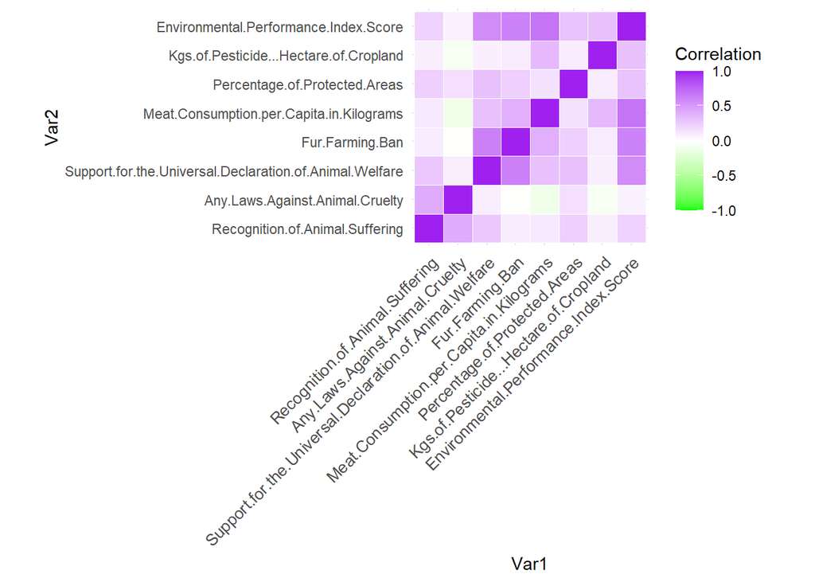

```r
# Visualize correlation matrix
ggplot(melt(correlation_matrix), aes(Var1, Var2, fill = value)) +
  geom_tile(color = "white") +
  scale_fill_gradient2(low = "green", high = "purple", mid = "white",
                       midpoint = 0, limit = c(-1,1), space = "Lab",
                       name="Correlation") +
  theme_minimal() +
  theme(axis.text.x = element_text(angle = 45, vjust = 1, size = 10, hjust = 1)) +
  coord_fixed()
```

Q- Compute the distance between the countries across the different dimensions? Calculating the Euclidean distance between countries across different dimensions allows us to quantify the dissimilarity or similarity between countries based on their attribute values. The Euclidean distance is used because it measures the straight-line distance between two points in a multidimensional space, making it suitable for comparing countries across multiple variables.

```r
matstd.data <- scale(animal_data)

# Creating a (Euclidean) distance matrix of the standardized data
dist.data <- dist(matstd.data, method="euclidean")
colnames(dist.data) <- rownames(dist.data)

dist.data
```

```
##                Luxembourg United Kingdom   Austria   Czechia   Belgium
## United Kingdom  1.1175024
## Austria         1.1857060      0.2776055
## Czechia         1.8660851      0.9740492 0.9167705
## Belgium         2.1179972      1.3476595 1.3937689 1.6131120
## Croatia         2.4776921      2.5957468 2.5936783 2.6430474 3.0026097
## Sweden          2.9073636      2.1354564 2.1496249 1.7707168 2.5429330
## Netherlands     3.1418658      2.1662596 2.1405630 2.1382930 1.2146746
## Bulgaria        2.2100430      2.1793046 2.2238502 2.0038381 2.5105270
## Switzerland     3.3182484      2.4032102 2.4353591 2.2688971 2.1165702
## Greece          1.5418573      1.5130728 1.5383659 1.7190682 1.9454691
## Denmark         2.4526881      1.6509240 1.7136792 1.4451283 2.1393042
## Germany         1.3402834      1.4821370 1.4438245 1.9800598 2.0577004
## Poland          1.7987238      2.0057952 1.9321636 2.0592221 2.5352604
## Estonia         2.5694667      1.8991289 1.9335254 1.3873248 2.1105022
## Finland         2.7231437      1.8739707 1.8889039 1.4478082 2.3187437
## New Zealand     2.5351231      2.3378907 2.2265427 2.6717064 2.1685308
## France          1.8508026      1.2120559 1.1927888 1.4292100 1.6397012
## Ireland         3.6285453      2.9414132 3.0861759 2.9466270 2.1213601
## Latvia          2.7742961      2.0611279 2.0569105 1.4335038 2.1892539
## Hungary         2.3576808      1.7126611 1.6581911 1.2596064 1.9153244
## Spain           1.9144266      1.4550630 1.3065262 1.5432851 1.9403153
## Lithuania       2.7880759      2.0192891 1.9605673 1.3588429 2.1943958
## Norway          3.5168078      2.9700712 3.0028648 2.7633802 3.2128924
## Italy           2.4797575      1.7516053 1.6948140 1.7821714 1.3122443
## Portugal        2.4546957      1.7990920 1.6674017 1.7059516 1.6262041
## Cyprus          3.0983569      2.3924668 2.3528083 2.3797276 1.4687622
## Malta           3.2811244      2.9982920 2.9492137 3.4006426 2.1752236
## Romania         2.4385891      1.9324933 1.9623778 1.5370751 2.2264884
## Tanzania        4.6397896      4.6724776 4.7493046 4.4227536 4.5782759
## Chile           3.2850330      2.6371645 2.5491845 2.3242911 2.1605676
## Brazil          3.0398715      2.7472211 2.6067754 2.6121357 2.5218945
## Mexico          4.3162088      3.7669424 3.7483475 3.3258456 3.6245294
## Canada          3.8015956      3.0238879 2.9814459 2.6297668 2.9919428
## Japan           4.2259675      3.9796349 4.0167400 4.3312953 3.2645162
## Indonesia       5.0141448      4.4964278 4.5645573 3.9515879 4.1715001
## India           5.7877878      5.2173697 5.2735970 4.6158882 4.7757990
## Peru            4.3441100      3.9573993 4.0162936 3.5864891 3.6449082
## Israel          4.7481319      4.2976136 4.2123586 4.4199807 3.5959685
## United States   3.8780834      3.2131102 3.0525067 2.8330273 3.4006821
```

[output cut: 749 more lines]

```
## Uruguay
## Colombia
## Morocco
## Niger
## Argentina
## Egypt
## Russia
## Ethiopia
## Mali
## Algeria
## Belarus
## Azerbaijan
## Iran
## Vietnam        1.3739568
## China          4.0379530 3.4925132
```

Each cell in the distance matrix represents the Euclidean distance between pairs of countries, with row and column names corresponding to the respective country names. Larger values in the distance matrix indicate greater dissimilarity between countries, while smaller values signify similarity in their attribute profiles across dimensions. This distance matrix serves as a quantitative tool for assessing relationships between countries in a multidimensional attribute space, facilitating tasks such as clustering similar countries, identifying outliers, and analyzing patterns and trends in the data.

#Optimal Number Of Clusters

```r
#CLUSTER ANALYSIS

matstd.animal_data <- scale(animal_data[,1:9])

# Creating a (Euclidean) distance matrix of the standardized data
dist.animal_data <- dist(matstd.animal_data, method="euclidean")
dist.animal_data
```

```
##                Luxembourg United Kingdom   Austria   Czechia   Belgium
## United Kingdom  1.1125886
## Austria         1.1772843      0.2752105
## Czechia         1.8587587      0.9721676 0.9164530
## Belgium         2.1041019      1.3406234 1.3900940 1.6112723
## Croatia         2.4638155      2.5909836 2.5908640 2.6412791 3.0025454
## Sweden          2.8889410      2.1238757 2.1415882 1.7633292 2.5415266
## Netherlands     3.1178261      2.1476632 2.1262820 2.1266620 1.2059039
## Bulgaria        2.1673301      2.1545229 2.2046848 1.9859428 2.5033128
## Switzerland     3.2884051      2.3791302 2.4164411 2.2516981 2.1069264
## Greece          1.4674017      1.4674726 1.5020524 1.6912241 1.9316904
## Denmark         2.4058496      1.6083842 1.6804225 1.4110808 2.1263771
## Germany         1.2434056      1.4283608 1.3984207 1.9514970 2.0414508
## Poland          1.7239847      1.9637715 1.8960063 2.0296181 2.5207458
## Estonia         2.5167629      1.8536629 1.8964790 1.3417810 2.0924387
## Finland         2.6730135      1.8273446 1.8504833 1.4036334 2.3020312
## New Zealand     2.4794864      2.2992094 2.1926287 2.6469307 2.1495899
## France          1.7682014      1.1285638 1.1216813 1.3773375 1.6111730
## Ireland         3.5869490      2.9078367 3.0592502 2.9216754 2.0992274
## Latvia          2.7152389      2.0080591 2.0118220 1.3753422 2.1646693
## Hungary         2.2813455      1.6409498 1.5948261 1.1839792 1.8825387
## Spain           1.8140035      1.3637955 1.2187408 1.4772219 1.9047718
## Lithuania       2.7181951      1.9523467 1.9010926 1.2803618 2.1615775
## Norway          3.4496717      2.9130470 2.9533954 2.7142639 3.1823893
## Italy           2.3821626      1.6513272 1.6038524 1.7035061 1.2339008
## Portugal        2.3471734      1.6911248 1.5642086 1.6137146 1.5548786
## Cyprus          2.9994452      2.2961689 2.2653426 2.2998390 1.3680894
## Malta           3.1802652      2.9148104 2.8729832 3.3394770 2.1005487
## Romania         2.2751654      1.7711546 1.8188777 1.3619662 2.1338745
## Tanzania        4.5440569      4.5976303 4.6820238 4.3547741 4.5251489
## Chile           3.1363034      2.4886218 2.4081363 2.1778145 2.0316877
## Brazil          2.8778347      2.6043028 2.4683532 2.4820566 2.4117964
## Mexico          4.1351054      3.5926800 3.5845076 3.1483557 3.4852973
## Canada          3.5872023      2.7950560 2.7640753 2.3916751 2.8140099
## Japan           4.0297746      3.8043751 3.8540437 4.1873134 3.0976123
## Indonesia       4.8428085      4.3347584 4.4150971 3.7852696 4.0352737
## India           5.6217974      5.0600620 5.1269206 4.4542037 4.6392205
## Peru            4.0793007      3.7056904 3.7817315 3.3314354 3.4233889
## Israel          4.4844079      4.0435592 3.9660394 4.1940003 3.3456506
## United States   3.5444760      2.8576829 2.6954864 2.4581368 3.1292244
```

[output cut: 749 more lines]

```
## Uruguay
## Colombia
## Morocco
## Niger
## Argentina
## Egypt
## Russia
## Ethiopia
## Mali
## Algeria
## Belarus
## Azerbaijan
## Iran
## Vietnam        1.3584881
## China          4.0112969 3.4829990
```

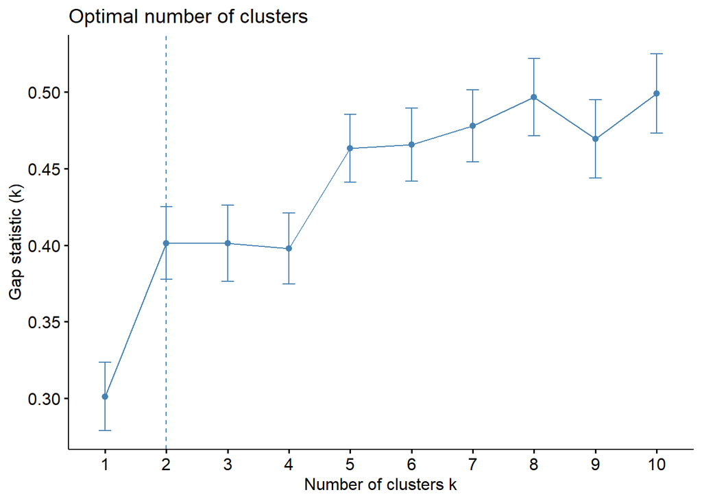

```r
fviz_nbclust(matstd.animal_data, kmeans, method = "gap_stat")
```

Optimal Number Of Cluster is 2:

This means that the data can be effectively grouped into two distinct clusters based on their attribute profiles across multiple dimensions. In other words, the countries in the dataset exhibit two distinct patterns or clusters of behavior regarding the variables included in the analysis. This information can be valuable for understanding the underlying structure of the data, identifying similarities and differences between groups of countries, and potentially uncovering meaningful patterns or trends that may exist within the dataset.

```r
# Hierarchial Clusiering
res.hc <- matstd.animal_data %>% scale() %>% dist(method = "euclidean") %>%
  hclust(method = "ward.D2")
```

```r
(kmeans2.animal_data <- kmeans(matstd.animal_data,2,nstart = 10))
```

```
## K-means clustering with 2 clusters of sizes 37, 30
##
## Cluster means:
##   Recognition.of.Animal.Sentience Recognition.of.Animal.Suffering
## 1                       0.5269122                       0.2648734
## 2                      -0.6498584                      -0.3266772
##   Any.Laws.Against.Animal.Cruelty
## 1                      0.08606147
## 2                     -0.10614248
##   Support.for.the.Universal.Declaration.of.Animal.Welfare Fur.Farming.Ban
## 1                                               0.5799261       0.6107582
## 2                                              -0.7152422      -0.7532685
##   Meat.Consumption.per.Capita.in.Kilograms Percentage.of.Protected.Areas
## 1                                0.6056056                     0.3351516
## 2                               -0.7469136                    -0.4133536
##   Kgs.of.Pesticide...Hectare.of.Cropland Environmental.Performance.Index.Score
## 1                              0.2533881                             0.7753424
## 2                             -0.3125120                            -0.9562556
##
## Clustering vector:
##     Luxembourg United Kingdom        Austria        Czechia        Belgium
##              1              1              1              1              1
##        Croatia         Sweden    Netherlands       Bulgaria    Switzerland
##              1              1              1              1              1
##         Greece        Denmark        Germany         Poland        Estonia
##              1              1              1              1              1
##        Finland    New Zealand         France        Ireland         Latvia
##              1              1              1              1              1
##        Hungary          Spain      Lithuania         Norway          Italy
##              1              1              1              1              1
##       Portugal         Cyprus          Malta        Romania       Tanzania
##              1              1              1              1              2
##          Chile         Brazil         Mexico         Canada          Japan
##              1              1              1              1              1
##      Indonesia          India           Peru         Israel  United States
##              2              2              2              1              1
##      Venezuela      Australia       Thailand         Turkey         Zambia
##              2              1              2              2              2
##       Malaysia       Zimbabwe          Kenya        Ukraine   Saudi Arabia
##              2              2              2              2              2
##   South Africa        Myanmar        Uruguay       Colombia        Morocco
##              2              2              2              2              2
##          Niger      Argentina          Egypt         Russia       Ethiopia
##              2              2              2              2              2
##           Mali        Algeria        Belarus     Azerbaijan           Iran
##              2              2              2              2              2
##        Vietnam          China
##              2              2
##
## Within cluster sum of squares by cluster:
## [1] 142.2089 269.2551
##  (between_SS / total_SS =  30.7 %)
##
## Available components:
##
## [1] "cluster"      "centers"      "totss"        "withinss"     "tot.withinss"
## [6] "betweenss"    "size"         "iter"         "ifault"
```

```r
# Computing the percentage of variation accounted for. Two clusters
perc.var.2 <- round(100*(1 - kmeans2.animal_data$betweenss/kmeans2.animal_data$totss),1)
names(perc.var.2) <- "Perc. 2 clus"
perc.var.2
```

```
## Perc. 2 clus
##         69.3
```

Cluster classification:

```r
clus1 <- matrix(names(kmeans2.animal_data$cluster[kmeans2.animal_data$cluster == 1]),
                ncol=1, nrow=length(kmeans2.animal_data$cluster[kmeans2.animal_data$cluster == 1]))
colnames(clus1) <- "Cluster 1"
clus2 <- matrix(names(kmeans2.animal_data$cluster[kmeans2.animal_data$cluster == 2]),
                ncol=1, nrow=length(kmeans2.animal_data$cluster[kmeans2.animal_data$cluster == 2]))
colnames(clus2) <- "Cluster 2"



list(clus1,clus2)
```

```
## [[1]]
##       Cluster 1
##  [1,] "Luxembourg"
##  [2,] "United Kingdom"
##  [3,] "Austria"
##  [4,] "Czechia"
##  [5,] "Belgium"
##  [6,] "Croatia"
##  [7,] "Sweden"
##  [8,] "Netherlands"
##  [9,] "Bulgaria"
## [10,] "Switzerland"
## [11,] "Greece"
## [12,] "Denmark"
## [13,] "Germany"
```

[output cut: 57 more lines]

Cluster Visualization:

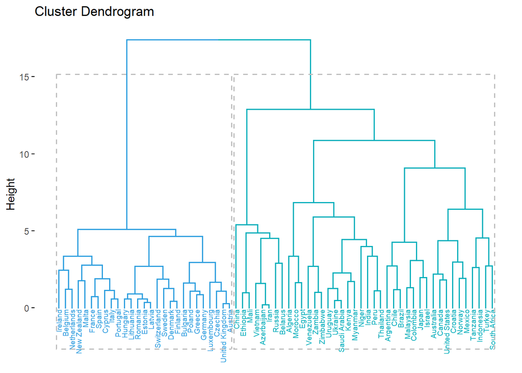

```r
fviz_dend(res.hc, k = 2, # Cut in four groups
          cex = 0.5, # label size
          k_colors = c("#2E9FDF", "#00AFBB", "#E7B800", "#FC4E07"),
          color_labels_by_k = TRUE, # color labels by groups
          rect = TRUE # Add rectangle around groups
)
```

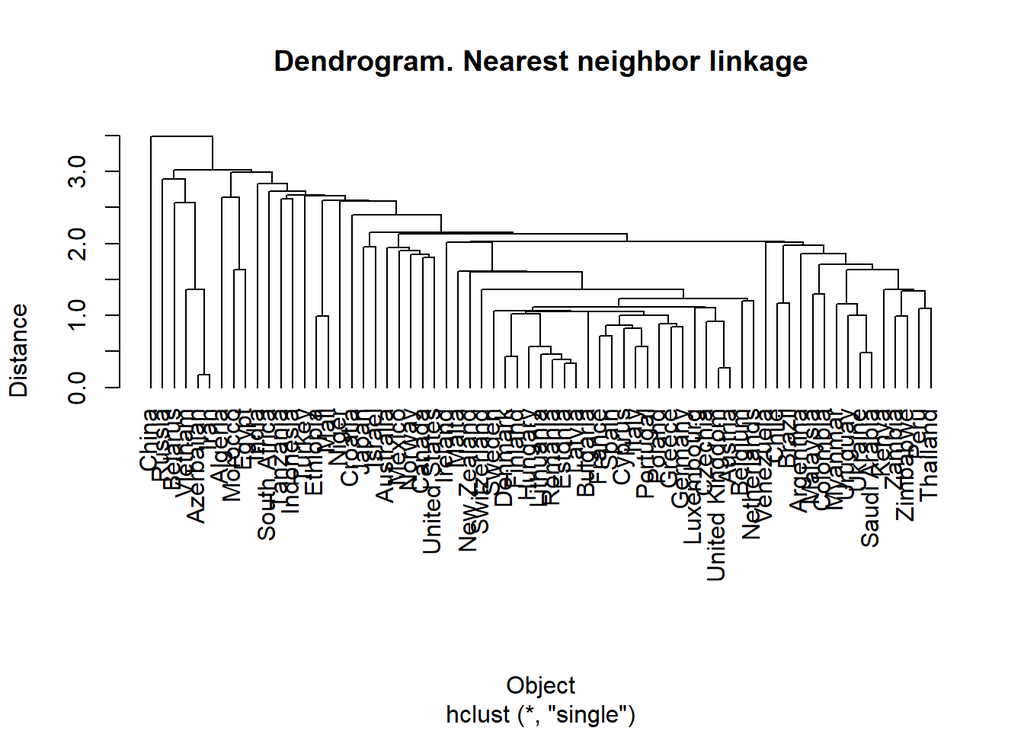

```r
# Invoking hclust command (cluster analysis by single linkage method)
clusl_d.nn <- hclust(dist.animal_data, method = "single")
plot(clusl_d.nn, hang=-1,xlab="Object",ylab="Distance",
     main="Dendrogram. Nearest neighbor linkage")
```

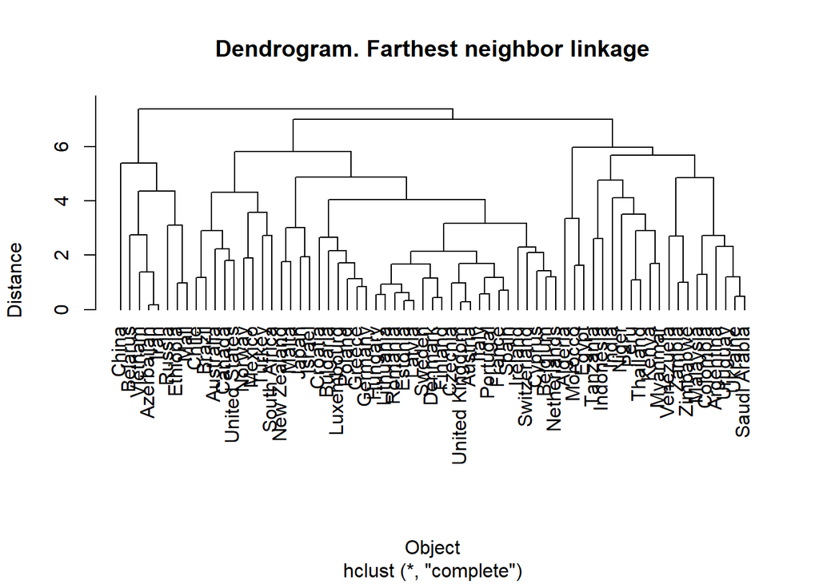

```r
#Default - Complete
clusl_d.fn <- hclust(dist.animal_data)
plot(clusl_d.fn,hang=-1,xlab="Object",ylab="Distance",
     main="Dendrogram. Farthest neighbor linkage")
```

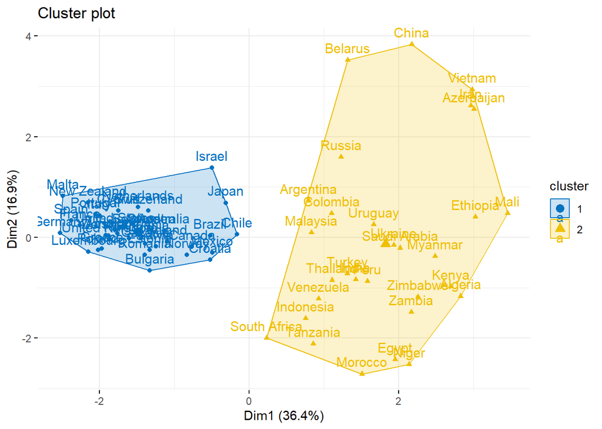

```r
set.seed(123)
km.res <- kmeans(matstd.animal_data, 2, nstart = 25)
# Visualize
fviz_cluster(km.res, data = matstd.animal_data, ellipse.type = "convex",palette = "jco",ggtheme = theme_minimal())
```

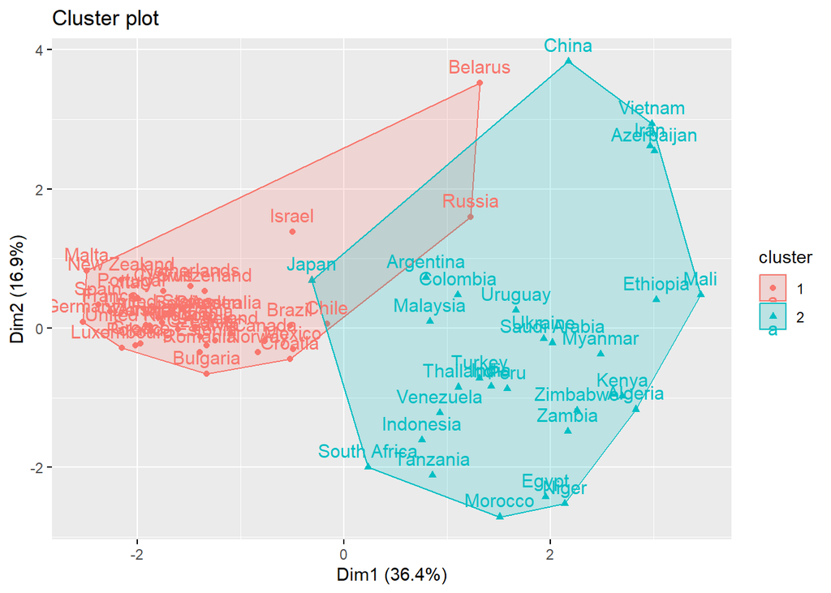

```r
# If your data has outliears , use PAM method
pam.res <- pam(matstd.animal_data, 2)
# Visualize
fviz_cluster(pam.res)
```

Standard Deviations and Proportion of Variance: The standard deviations represent the variability of the principal components (PCs). The first PC (PC1) has the highest standard deviation, followed by PC2 and so on. The proportion of variance indicates the amount of total variance captured by each PC. PC1 captures 47.68% of the total variance, PC2 captures 23.36%, and so forth.

Cumulative Proportion of Variance: This shows the cumulative proportion of variance explained by each PC. For example, PC1 and PC2 combined capture 71.04% of the total variance.

Rotation Matrix: The rotation matrix shows the loadings (correlation coefficients) of each original variable on each principal component. For instance, PC1 has positive loadings for variables related to meat consumption, fur farming ban, and environmental performance index score, while it has negative loadings for variables related to recognition of animal suffering and laws against animal cruelty.

PCA is used to reduce the dimensionality of the data while preserving most of its variability. It helps in understanding the underlying structure of the dataset, identifying patterns, and exploring relationships between variables. The visualization of PCA results, such as biplots or scree plots, can further aid in interpreting the relationships between countries based on the selected variables.

```r
animal_data_pca <- prcomp(correlation_matrix,scale=TRUE)
animal_data_pca
```

```
## Standard deviations (1, .., p=8):
## [1] 1.952967e+00 1.367167e+00 1.012987e+00 7.444876e-01 6.673186e-01
## [6] 4.010200e-01 3.608864e-01 2.642358e-17
##
## Rotation (n x k) = (8 x 8):
##                                                                 PC1        PC2
## Recognition.of.Animal.Suffering                         -0.34322857  0.1929208
## Any.Laws.Against.Animal.Cruelty                         -0.43936330  0.1724908
## Support.for.the.Universal.Declaration.of.Animal.Welfare  0.30666392  0.4988351
## Fur.Farming.Ban                                          0.41145913  0.3455005
## Meat.Consumption.per.Capita.in.Kilograms                 0.42996450 -0.1974444
## Percentage.of.Protected.Areas                           -0.04457076  0.3126622
## Kgs.of.Pesticide...Hectare.of.Cropland                   0.15522102 -0.6466828
## Environmental.Performance.Index.Score                    0.46353325  0.0994026
##                                                                PC3          PC4
## Recognition.of.Animal.Suffering                          0.3490064 -0.750283336
## Any.Laws.Against.Animal.Cruelty                          0.2444527  0.287311168
## Support.for.the.Universal.Declaration.of.Animal.Welfare  0.1345689  0.057477100
## Fur.Farming.Ban                                          0.1045853  0.276474562
## Meat.Consumption.per.Capita.in.Kilograms                 0.1177588 -0.379068824
## Percentage.of.Protected.Areas                           -0.8619358 -0.272177559
## Kgs.of.Pesticide...Hectare.of.Cropland                  -0.1006526 -0.007685061
## Environmental.Performance.Index.Score                    0.1498635 -0.238647336
##                                                                 PC5         PC6
## Recognition.of.Animal.Suffering                         -0.28376490 -0.15817483
## Any.Laws.Against.Animal.Cruelty                          0.40094316  0.37707982
## Support.for.the.Universal.Declaration.of.Animal.Welfare -0.46376952  0.51019606
## Fur.Farming.Ban                                         -0.11188625 -0.58067524
## Meat.Consumption.per.Capita.in.Kilograms                 0.47987231 -0.06254641
## Percentage.of.Protected.Areas                            0.08250688  0.08275411
## Kgs.of.Pesticide...Hectare.of.Cropland                  -0.45698205  0.25701093
## Environmental.Performance.Index.Score                    0.29189717  0.39811162
##                                                                PC7        PC8
## Recognition.of.Animal.Suffering                         -0.1802886 -0.1489944
## Any.Laws.Against.Animal.Cruelty                         -0.2249615 -0.5304241
## Support.for.the.Universal.Declaration.of.Animal.Welfare  0.3732971 -0.1448292
## Fur.Farming.Ban                                         -0.3693797 -0.3712289
## Meat.Consumption.per.Capita.in.Kilograms                 0.4379278 -0.4388801
## Percentage.of.Protected.Areas                           -0.1285404 -0.2303553
## Kgs.of.Pesticide...Hectare.of.Cropland                  -0.3083641 -0.4213576
## Environmental.Performance.Index.Score                   -0.5811235  0.3382943
```

```r
summary(animal_data_pca)
```

```
## Importance of components:
##                           PC1    PC2    PC3     PC4     PC5    PC6     PC7
## Standard deviation     1.9530 1.3672 1.0130 0.74449 0.66732 0.4010 0.36089
## Proportion of Variance 0.4768 0.2336 0.1283 0.06928 0.05566 0.0201 0.01628
## Cumulative Proportion  0.4768 0.7104 0.8387 0.90795 0.96362 0.9837 1.00000
##                              PC8
## Standard deviation     2.642e-17
## Proportion of Variance 0.000e+00
## Cumulative Proportion  1.000e+00
```

```r
library(factoextra)



# Eigenvalues are sdev^2
(eigen_animal_data <- animal_data_pca$sdev^2)
```

```
## [1] 3.814081e+00 1.869145e+00 1.026142e+00 5.542618e-01 4.453141e-01
## [6] 1.608171e-01 1.302390e-01 6.982056e-34
```

```r
names(eigen_animal_data) <- paste("PC",1:8,sep="")
eigen_animal_data
```

```
##          PC1          PC2          PC3          PC4          PC5          PC6
## 3.814081e+00 1.869145e+00 1.026142e+00 5.542618e-01 4.453141e-01 1.608171e-01
##          PC7          PC8
## 1.302390e-01 6.982056e-34
```

```r
sumlambdas <- sum(eigen_animal_data)
sumlambdas
```

```
## [1] 8
```

```r
propvar <- eigen_animal_data/sumlambdas
propvar
```

```
##          PC1          PC2          PC3          PC4          PC5          PC6
## 4.767601e-01 2.336431e-01 1.282678e-01 6.928273e-02 5.566426e-02 2.010213e-02
##          PC7          PC8
## 1.627988e-02 8.727570e-35
```

```r
cumvar_animal_data <- cumsum(propvar)
cumvar_animal_data
```

```
##       PC1       PC2       PC3       PC4       PC5       PC6       PC7       PC8
## 0.4767601 0.7104032 0.8386710 0.9079537 0.9636180 0.9837201 1.0000000 1.0000000
```

```r
matlambdas <- rbind(eigen_animal_data,propvar,cumvar_animal_data)
rownames(matlambdas) <- c("Eigenvalues","Prop. variance","Cum. prop. variance")
round(matlambdas,4)
```

```
##                        PC1    PC2    PC3    PC4    PC5    PC6    PC7 PC8
## Eigenvalues         3.8141 1.8691 1.0261 0.5543 0.4453 0.1608 0.1302   0
## Prop. variance      0.4768 0.2336 0.1283 0.0693 0.0557 0.0201 0.0163   0
## Cum. prop. variance 0.4768 0.7104 0.8387 0.9080 0.9636 0.9837 1.0000   1
```

```r
summary(animal_data_pca)
```

```
## Importance of components:
##                           PC1    PC2    PC3     PC4     PC5    PC6     PC7
## Standard deviation     1.9530 1.3672 1.0130 0.74449 0.66732 0.4010 0.36089
## Proportion of Variance 0.4768 0.2336 0.1283 0.06928 0.05566 0.0201 0.01628
## Cumulative Proportion  0.4768 0.7104 0.8387 0.90795 0.96362 0.9837 1.00000
##                              PC8
## Standard deviation     2.642e-17
## Proportion of Variance 0.000e+00
## Cumulative Proportion  1.000e+00
```

```r
animal_data_pca$rotation
```

```
##                                                                 PC1        PC2
## Recognition.of.Animal.Suffering                         -0.34322857  0.1929208
## Any.Laws.Against.Animal.Cruelty                         -0.43936330  0.1724908
## Support.for.the.Universal.Declaration.of.Animal.Welfare  0.30666392  0.4988351
## Fur.Farming.Ban                                          0.41145913  0.3455005
## Meat.Consumption.per.Capita.in.Kilograms                 0.42996450 -0.1974444
## Percentage.of.Protected.Areas                           -0.04457076  0.3126622
## Kgs.of.Pesticide...Hectare.of.Cropland                   0.15522102 -0.6466828
## Environmental.Performance.Index.Score                    0.46353325  0.0994026
##                                                                PC3          PC4
## Recognition.of.Animal.Suffering                          0.3490064 -0.750283336
## Any.Laws.Against.Animal.Cruelty                          0.2444527  0.287311168
## Support.for.the.Universal.Declaration.of.Animal.Welfare  0.1345689  0.057477100
## Fur.Farming.Ban                                          0.1045853  0.276474562
## Meat.Consumption.per.Capita.in.Kilograms                 0.1177588 -0.379068824
## Percentage.of.Protected.Areas                           -0.8619358 -0.272177559
## Kgs.of.Pesticide...Hectare.of.Cropland                  -0.1006526 -0.007685061
## Environmental.Performance.Index.Score                    0.1498635 -0.238647336
##                                                                 PC5         PC6
## Recognition.of.Animal.Suffering                         -0.28376490 -0.15817483
## Any.Laws.Against.Animal.Cruelty                          0.40094316  0.37707982
## Support.for.the.Universal.Declaration.of.Animal.Welfare -0.46376952  0.51019606
## Fur.Farming.Ban                                         -0.11188625 -0.58067524
## Meat.Consumption.per.Capita.in.Kilograms                 0.47987231 -0.06254641
## Percentage.of.Protected.Areas                            0.08250688  0.08275411
## Kgs.of.Pesticide...Hectare.of.Cropland                  -0.45698205  0.25701093
## Environmental.Performance.Index.Score                    0.29189717  0.39811162
##                                                                PC7        PC8
## Recognition.of.Animal.Suffering                         -0.1802886 -0.1489944
## Any.Laws.Against.Animal.Cruelty                         -0.2249615 -0.5304241
## Support.for.the.Universal.Declaration.of.Animal.Welfare  0.3732971 -0.1448292
## Fur.Farming.Ban                                         -0.3693797 -0.3712289
## Meat.Consumption.per.Capita.in.Kilograms                 0.4379278 -0.4388801
## Percentage.of.Protected.Areas                           -0.1285404 -0.2303553
## Kgs.of.Pesticide...Hectare.of.Cropland                  -0.3083641 -0.4213576
## Environmental.Performance.Index.Score                   -0.5811235  0.3382943
```

```r
print(animal_data_pca)
```

```
## Standard deviations (1, .., p=8):
## [1] 1.952967e+00 1.367167e+00 1.012987e+00 7.444876e-01 6.673186e-01
## [6] 4.010200e-01 3.608864e-01 2.642358e-17
##
## Rotation (n x k) = (8 x 8):
##                                                                 PC1        PC2
## Recognition.of.Animal.Suffering                         -0.34322857  0.1929208
## Any.Laws.Against.Animal.Cruelty                         -0.43936330  0.1724908
## Support.for.the.Universal.Declaration.of.Animal.Welfare  0.30666392  0.4988351
## Fur.Farming.Ban                                          0.41145913  0.3455005
## Meat.Consumption.per.Capita.in.Kilograms                 0.42996450 -0.1974444
## Percentage.of.Protected.Areas                           -0.04457076  0.3126622
## Kgs.of.Pesticide...Hectare.of.Cropland                   0.15522102 -0.6466828
## Environmental.Performance.Index.Score                    0.46353325  0.0994026
##                                                                PC3          PC4
## Recognition.of.Animal.Suffering                          0.3490064 -0.750283336
## Any.Laws.Against.Animal.Cruelty                          0.2444527  0.287311168
## Support.for.the.Universal.Declaration.of.Animal.Welfare  0.1345689  0.057477100
## Fur.Farming.Ban                                          0.1045853  0.276474562
## Meat.Consumption.per.Capita.in.Kilograms                 0.1177588 -0.379068824
## Percentage.of.Protected.Areas                           -0.8619358 -0.272177559
## Kgs.of.Pesticide...Hectare.of.Cropland                  -0.1006526 -0.007685061
## Environmental.Performance.Index.Score                    0.1498635 -0.238647336
##                                                                 PC5         PC6
## Recognition.of.Animal.Suffering                         -0.28376490 -0.15817483
## Any.Laws.Against.Animal.Cruelty                          0.40094316  0.37707982
## Support.for.the.Universal.Declaration.of.Animal.Welfare -0.46376952  0.51019606
## Fur.Farming.Ban                                         -0.11188625 -0.58067524
## Meat.Consumption.per.Capita.in.Kilograms                 0.47987231 -0.06254641
## Percentage.of.Protected.Areas                            0.08250688  0.08275411
## Kgs.of.Pesticide...Hectare.of.Cropland                  -0.45698205  0.25701093
## Environmental.Performance.Index.Score                    0.29189717  0.39811162
##                                                                PC7        PC8
## Recognition.of.Animal.Suffering                         -0.1802886 -0.1489944
## Any.Laws.Against.Animal.Cruelty                         -0.2249615 -0.5304241
## Support.for.the.Universal.Declaration.of.Animal.Welfare  0.3732971 -0.1448292
## Fur.Farming.Ban                                         -0.3693797 -0.3712289
## Meat.Consumption.per.Capita.in.Kilograms                 0.4379278 -0.4388801
## Percentage.of.Protected.Areas                           -0.1285404 -0.2303553
## Kgs.of.Pesticide...Hectare.of.Cropland                  -0.3083641 -0.4213576
## Environmental.Performance.Index.Score                   -0.5811235  0.3382943
```

```r
animal_data_pca$x
```

```
##                                                                 PC1        PC2
## Recognition.of.Animal.Suffering                         -2.28831897  0.3367793
## Any.Laws.Against.Animal.Cruelty                         -3.20692472  0.1162394
## Support.for.the.Universal.Declaration.of.Animal.Welfare  1.04873932  1.5057126
## Fur.Farming.Ban                                          1.65281506  0.9691809
## Meat.Consumption.per.Capita.in.Kilograms                 1.70462002 -1.0739995
## Percentage.of.Protected.Areas                           -0.85168049  0.7364704
## Kgs.of.Pesticide...Hectare.of.Cropland                   0.01334753 -2.8281123
## Environmental.Performance.Index.Score                    1.92740226  0.2377292
##                                                                PC3        PC4
## Recognition.of.Animal.Suffering                          0.8676663 -1.2557524
## Any.Laws.Against.Animal.Cruelty                          0.6070185  0.9642964
## Support.for.the.Universal.Declaration.of.Animal.Welfare  0.3118612  0.2712147
## Fur.Farming.Ban                                          0.2448125  0.8149101
## Meat.Consumption.per.Capita.in.Kilograms                 0.2967349 -0.4704806
## Percentage.of.Protected.Areas                           -2.3637623 -0.2704130
## Kgs.of.Pesticide...Hectare.of.Cropland                  -0.3201216  0.3851162
## Environmental.Performance.Index.Score                    0.3557905 -0.4388914
##                                                                PC5         PC6
## Recognition.of.Animal.Suffering                         -0.5093963 -0.28171560
## Any.Laws.Against.Animal.Cruelty                          0.7261262  0.17944715
## Support.for.the.Universal.Declaration.of.Animal.Welfare -0.8025090  0.48641291
## Fur.Farming.Ban                                         -0.1811153 -0.71833707
## Meat.Consumption.per.Capita.in.Kilograms                 0.8889208 -0.18768064
## Percentage.of.Protected.Areas                            0.1645936 -0.03291712
## Kgs.of.Pesticide...Hectare.of.Cropland                  -0.7738988  0.08852337
## Environmental.Performance.Index.Score                    0.4872788  0.46626700
##                                                                  PC7
## Recognition.of.Animal.Suffering                         -0.068916393
## Any.Laws.Against.Animal.Cruelty                          0.006713032
## Support.for.the.Universal.Declaration.of.Animal.Welfare  0.438852994
## Fur.Farming.Ban                                         -0.218733968
## Meat.Consumption.per.Capita.in.Kilograms                 0.543419592
## Percentage.of.Protected.Areas                            0.003797084
## Kgs.of.Pesticide...Hectare.of.Cropland                  -0.105061555
## Environmental.Performance.Index.Score                   -0.600070786
##                                                                   PC8
## Recognition.of.Animal.Suffering                          8.326673e-16
## Any.Laws.Against.Animal.Cruelty                         -1.054712e-15
## Support.for.the.Universal.Declaration.of.Animal.Welfare -2.914335e-16
## Fur.Farming.Ban                                          1.387779e-16
## Meat.Consumption.per.Capita.in.Kilograms                -1.387779e-16
## Percentage.of.Protected.Areas                            1.942890e-16
## Kgs.of.Pesticide...Hectare.of.Cropland                   5.551115e-16
## Environmental.Performance.Index.Score                    0.000000e+00
```

```r
# Different PCA Method.
res.pca <- PCA(animal_data[,1:9][,-1], graph = FALSE)
print(res.pca)
```

```
## **Results for the Principal Component Analysis (PCA)**
## The analysis was performed on 67 individuals, described by 8 variables
## *The results are available in the following objects:
##
##    name               description
## 1  "$eig"             "eigenvalues"
## 2  "$var"             "results for the variables"
## 3  "$var$coord"       "coord. for the variables"
## 4  "$var$cor"         "correlations variables - dimensions"
## 5  "$var$cos2"        "cos2 for the variables"
## 6  "$var$contrib"     "contributions of the variables"
## 7  "$ind"             "results for the individuals"
## 8  "$ind$coord"       "coord. for the individuals"
## 9  "$ind$cos2"        "cos2 for the individuals"
## 10 "$ind$contrib"     "contributions of the individuals"
## 11 "$call"            "summary statistics"
## 12 "$call$centre"     "mean of the variables"
## 13 "$call$ecart.type" "standard error of the variables"
## 14 "$call$row.w"      "weights for the individuals"
## 15 "$call$col.w"      "weights for the variables"
```

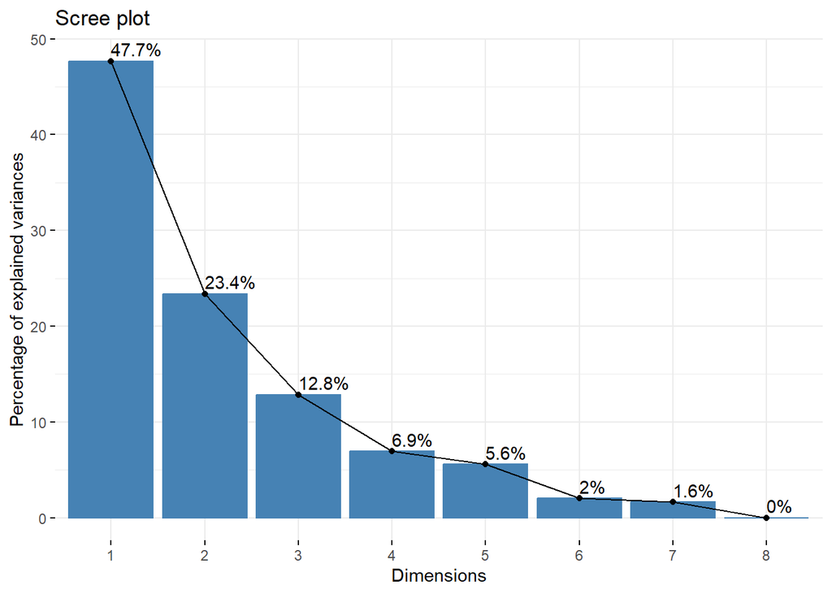

```r
fviz_eig(animal_data_pca, addlabels = TRUE)
```

```r
var <- get_pca_var(res.pca)
var
```

```
## Principal Component Analysis Results for variables
##  ===================================================
##   Name       Description
## 1 "$coord"   "Coordinates for the variables"
## 2 "$cor"     "Correlations between variables and dimensions"
## 3 "$cos2"    "Cos2 for the variables"
## 4 "$contrib" "contributions of the variables"
```

Based on the cumulative proportion of variance, you should select at least the first 3 principal components (PCs) for your PCA analysis to achieve a cumulative proportion of approximately 83%.

In your output: The cumulative proportion reaches 0.8387 after PC3. This means that the first 3 PCs collectively explain approximately 83.87% of the total variance in the data.

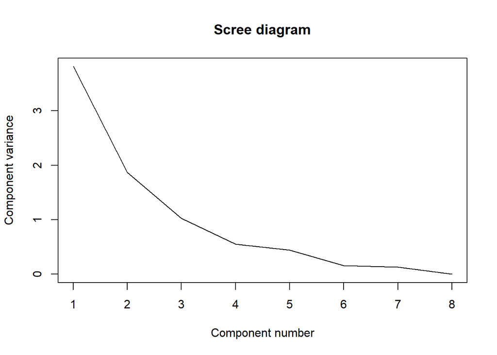

```r
plot(eigen_animal_data, xlab = "Component number", ylab = "Component variance", type = "l", main = "Scree diagram")
```

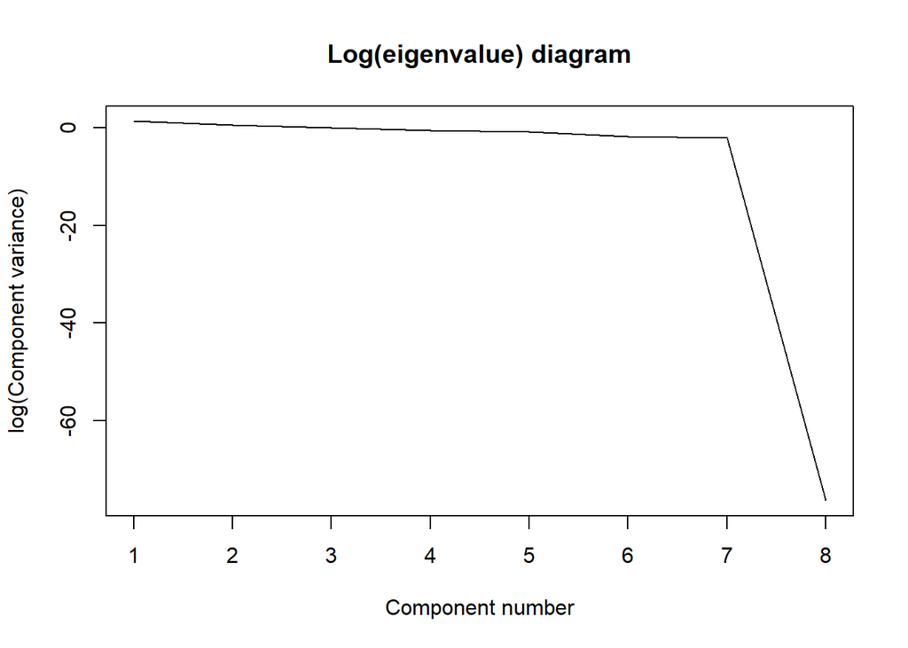

```r
plot(log(eigen_animal_data), xlab = "Component number",ylab = "log(Component variance)", type="l",main = "Log(eigenvalue) diagram")
```

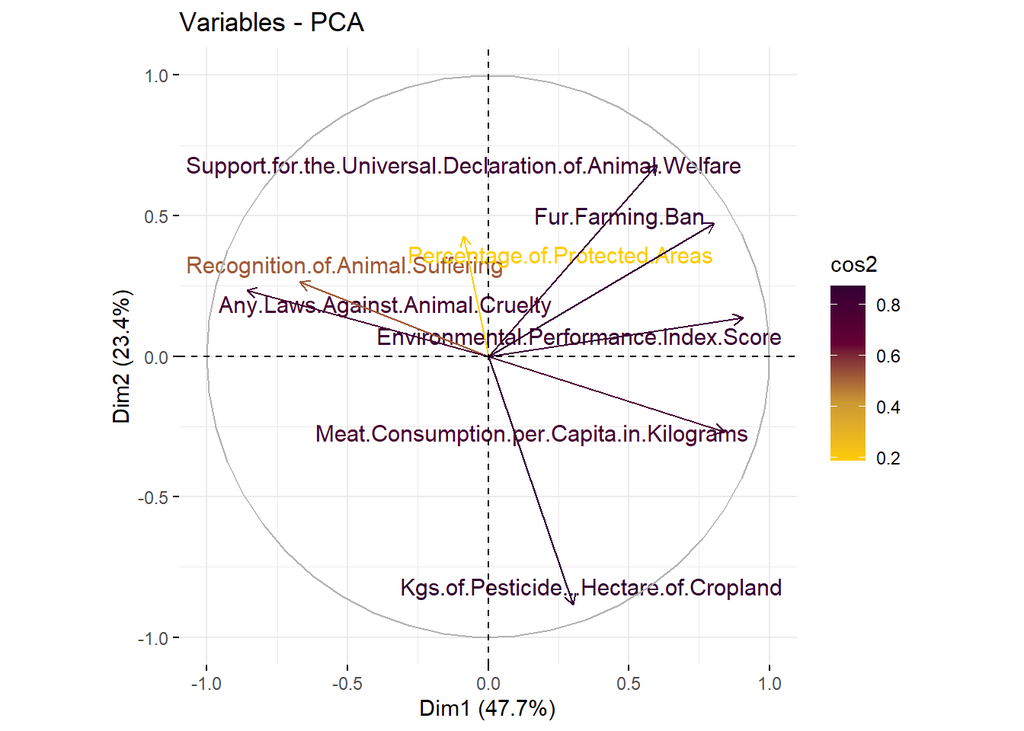

```r
fviz_pca_var(animal_data_pca,col.var = "cos2",
             gradient.cols = c("#FFCC00", "#CC9933", "#660033", "#330033"),
             repel = TRUE)
```

This visualization helps interpret how different variables contribute to the principal components identified through PCA, with the color indicating the strength of their contribution and the position in the scatterplot revealing their relationships with each other and with the principal components.

The length of the vector reflects the variance of the variable.

Correlation of the variables reflected by the angle between them. The smaller the angle, the more significant the correlation.

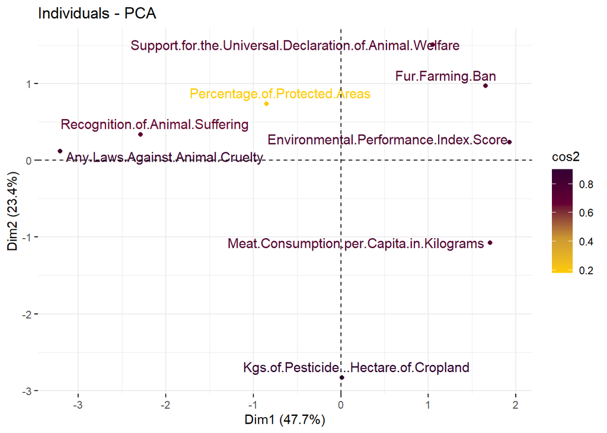

```r
fviz_pca_ind(animal_data_pca, col.ind = "cos2",
             gradient.cols = c("#FFCC00", "#CC9933", "#660033", "#330033"),
             repel = TRUE)
```

The visualization produced in a principal component analysis (PCA) plot displays individual observations as points in a two-dimensional space defined by the first two principal components.

It helps identify patterns, clusters, and outliers in the data, with points closer together indicating similarity and clusters representing groups of similar observations.

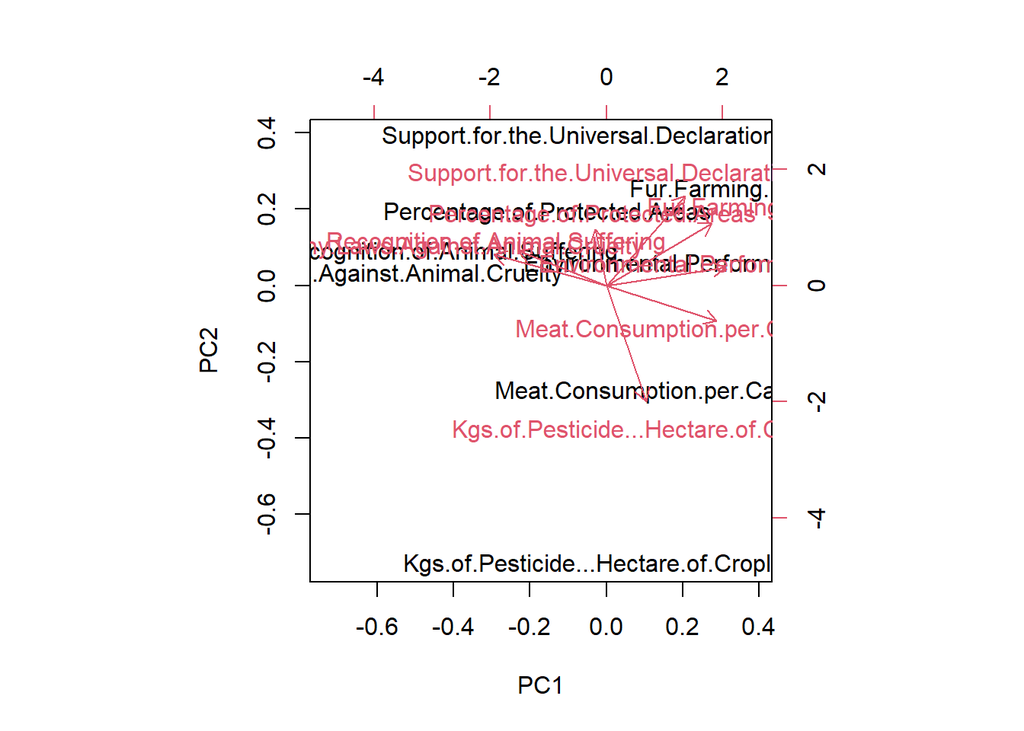

```r
biplot(animal_data_pca)
```

The visualization generated by fviz_pca_biplot() in a principal component analysis (PCA) plot combines information about both variables and individuals (observations) in the same plot.

Each variable is represented by an arrow, indicating its direction and magnitude in the PCA space. The length and direction of the arrow represent the contribution and relationship of the variable to the principal components, respectively.

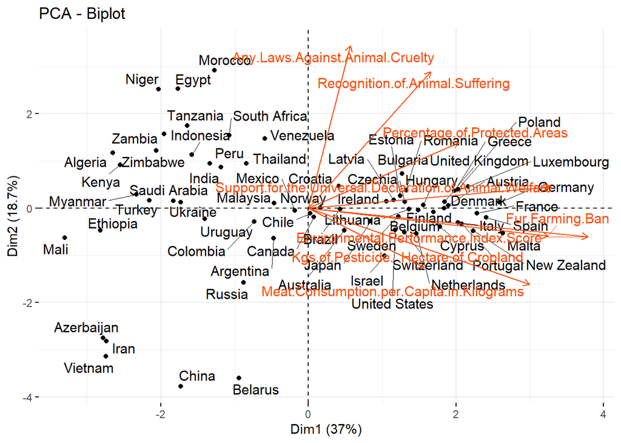

```r
fviz_pca_biplot(res.pca, repel = TRUE,
                col.var = "#FC4E07",
                )
```

```r
#FACTOR ANALYSIS
cov(animal_data[,-1])
```

```
##                                                         Recognition.of.Animal.Suffering
## Recognition.of.Animal.Suffering                                              0.15558571
## Any.Laws.Against.Animal.Cruelty                                              0.05744007
## Support.for.the.Universal.Declaration.of.Animal.Welfare                      0.10289462
## Fur.Farming.Ban                                                              0.03437359
## Meat.Consumption.per.Capita.in.Kilograms                                     1.23900724
## Percentage.of.Protected.Areas                                                1.03136364
## Kgs.of.Pesticide...Hectare.of.Cropland                                       0.11505494
## Environmental.Performance.Index.Score                                        1.47761194
## Total.Score                                                                 28.75904342
##                                                         Any.Laws.Against.Animal.Cruelty
## Recognition.of.Animal.Suffering                                             0.057440072
## Any.Laws.Against.Animal.Cruelty                                             0.120307553
## Support.for.the.Universal.Declaration.of.Animal.Welfare                     0.029398462
## Fur.Farming.Ban                                                            -0.003165988
## Meat.Consumption.per.Capita.in.Kilograms                                   -1.106062867
## Percentage.of.Protected.Areas                                               0.600757576
## Kgs.of.Pesticide...Hectare.of.Cropland                                     -0.077303048
## Environmental.Performance.Index.Score                                       0.405291723
## Total.Score                                                                14.476501583
##                                                         Support.for.the.Universal.Declaration.of.Animal.Welfare
## Recognition.of.Animal.Suffering                                                                      0.10289462
## Any.Laws.Against.Animal.Cruelty                                                                      0.02939846
## Support.for.the.Universal.Declaration.of.Animal.Welfare                                              0.87788331
## Fur.Farming.Ban                                                                                      0.54228856
## Meat.Consumption.per.Capita.in.Kilograms                                                             8.56075531
## Percentage.of.Protected.Areas                                                                        3.20863636
## Kgs.of.Pesticide...Hectare.of.Cropland                                                               0.25344483
## Environmental.Performance.Index.Score                                                                8.84468566
## Total.Score                                                                                         88.81225916
##                                                         Fur.Farming.Ban
## Recognition.of.Animal.Suffering                             0.034373587
## Any.Laws.Against.Animal.Cruelty                            -0.003165988
## Support.for.the.Universal.Declaration.of.Animal.Welfare     0.542288557
## Fur.Farming.Ban                                             0.852555405
## Meat.Consumption.per.Capita.in.Kilograms                   10.649613297
## Percentage.of.Protected.Areas                               2.430606061
## Kgs.of.Pesticide...Hectare.of.Cropland                      0.303939937
## Environmental.Performance.Index.Score                       9.503369516
## Total.Score                                                72.827073722
```

[output cut: 35 more lines]

```
## Meat.Consumption.per.Capita.in.Kilograms                                          330.2818390
## Percentage.of.Protected.Areas                                                      54.5545000
## Kgs.of.Pesticide...Hectare.of.Cropland                                             17.1462423
## Environmental.Performance.Index.Score                                             274.7776798
## Total.Score                                                                      1519.6548976
##                                                         Total.Score
## Recognition.of.Animal.Suffering                            28.75904
## Any.Laws.Against.Animal.Cruelty                            14.47650
## Support.for.the.Universal.Declaration.of.Animal.Welfare    88.81226
## Fur.Farming.Ban                                            72.82707
## Meat.Consumption.per.Capita.in.Kilograms                 1443.34412
## Percentage.of.Protected.Areas                             698.67774
## Kgs.of.Pesticide...Hectare.of.Cropland                     41.93298
## Environmental.Performance.Index.Score                    1519.65490
## Total.Score                                             16190.82106
```

```r
fit.pc <- principal(animal_data[,1:9][-1], nfactors=4, rotate="varimax")
fit.pc
```

```
## Principal Components Analysis
## Call: principal(r = animal_data[, 1:9][-1], nfactors = 4, rotate = "varimax")
## Standardized loadings (pattern matrix) based upon correlation matrix
##                                                           RC1   RC2   RC3   RC4
## Recognition.of.Animal.Suffering                          0.14  0.82  0.13  0.11
## Any.Laws.Against.Animal.Cruelty                         -0.02  0.85 -0.13  0.04
## Support.for.the.Universal.Declaration.of.Animal.Welfare  0.82  0.17 -0.05  0.19
## Fur.Farming.Ban                                          0.88 -0.04  0.01  0.09
## Meat.Consumption.per.Capita.in.Kilograms                 0.56 -0.06  0.63 -0.06
## Percentage.of.Protected.Areas                            0.20  0.13  0.07  0.96
## Kgs.of.Pesticide...Hectare.of.Cropland                  -0.02  0.01  0.89  0.09
## Environmental.Performance.Index.Score                    0.78  0.12  0.43  0.09
##                                                           h2   u2 com
## Recognition.of.Animal.Suffering                         0.72 0.28 1.2
## Any.Laws.Against.Animal.Cruelty                         0.74 0.26 1.0
## Support.for.the.Universal.Declaration.of.Animal.Welfare 0.73 0.27 1.2
## Fur.Farming.Ban                                         0.78 0.22 1.0
## Meat.Consumption.per.Capita.in.Kilograms                0.72 0.28 2.0
## Percentage.of.Protected.Areas                           0.98 0.02 1.1
## Kgs.of.Pesticide...Hectare.of.Cropland                  0.81 0.19 1.0
## Environmental.Performance.Index.Score                   0.82 0.18 1.6
##
##                        RC1  RC2  RC3  RC4
## SS loadings           2.42 1.46 1.42 1.00
## Proportion Var        0.30 0.18 0.18 0.12
## Cumulative Var        0.30 0.49 0.66 0.79
## Proportion Explained  0.38 0.23 0.23 0.16
## Cumulative Proportion 0.38 0.62 0.84 1.00
##
## Mean item complexity =  1.3
## Test of the hypothesis that 4 components are sufficient.
##
## The root mean square of the residuals (RMSR) is  0.08
##  with the empirical chi square  26.86  with prob <  1.5e-06
##
## Fit based upon off diagonal values = 0.93
```

```r
round(fit.pc$values, 3)
```

```
## [1] 2.963 1.493 1.051 0.793 0.585 0.559 0.334 0.223
```

```r
fit.pc$loadings
```

```
##
## Loadings:
##                                                         RC1    RC2    RC3
## Recognition.of.Animal.Suffering                          0.144  0.817  0.134
## Any.Laws.Against.Animal.Cruelty                                 0.852 -0.126
## Support.for.the.Universal.Declaration.of.Animal.Welfare  0.816  0.170
## Fur.Farming.Ban                                          0.876
## Meat.Consumption.per.Capita.in.Kilograms                 0.564         0.627
## Percentage.of.Protected.Areas                            0.195  0.129
## Kgs.of.Pesticide...Hectare.of.Cropland                                 0.894
## Environmental.Performance.Index.Score                    0.782  0.119  0.432
##                                                         RC4
## Recognition.of.Animal.Suffering                          0.113
## Any.Laws.Against.Animal.Cruelty
## Support.for.the.Universal.Declaration.of.Animal.Welfare  0.193
## Fur.Farming.Ban
## Meat.Consumption.per.Capita.in.Kilograms
## Percentage.of.Protected.Areas                            0.959
## Kgs.of.Pesticide...Hectare.of.Cropland
## Environmental.Performance.Index.Score
##
##                  RC1   RC2   RC3   RC4
## SS loadings    2.423 1.459 1.419 0.999
## Proportion Var 0.303 0.182 0.177 0.125
## Cumulative Var 0.303 0.485 0.663 0.787
```

```r
# Communalities
fit.pc$communality
```

```
##                         Recognition.of.Animal.Suffering
##                                               0.7189636
##                         Any.Laws.Against.Animal.Cruelty
##                                               0.7440914
## Support.for.the.Universal.Declaration.of.Animal.Welfare
##                                               0.7337538
##                                         Fur.Farming.Ban
##                                               0.7774183
##                Meat.Consumption.per.Capita.in.Kilograms
##                                               0.7182366
##                           Percentage.of.Protected.Areas
##                                               0.9801207
##                  Kgs.of.Pesticide...Hectare.of.Cropland
##                                               0.8076783
##                   Environmental.Performance.Index.Score
##                                               0.8191230
```

```r
fit.pc$scores
```

```
##                       RC1          RC2           RC3          RC4
## Luxembourg      0.8259732  0.073722530  0.1669123724  1.746316612
## United Kingdom  0.8976700  0.183383013  0.2482725441  0.613490858
## Austria         0.9062940  0.171628847  0.3486134669  0.551966107
## Czechia         0.9034683  0.203506591 -0.1464686408 -0.004612464
## Belgium         0.4893854  0.257719337  0.7438473285  0.322727111
## Croatia        -0.2645509 -0.028329246  0.1544318349  1.532012588
## Sweden          1.2125971  0.138219602 -0.3536805157 -0.821833824
## Netherlands     0.6147835  0.363084466  1.1659292044 -0.856601007
## Bulgaria        0.9333728 -0.018273448 -1.0127111249  1.317328616
## Switzerland     0.9733052  0.233041343  0.4478134061 -1.164381742
## Greece          1.0752698 -0.001638543 -0.2722317379  1.270562366
## Denmark         1.5901276  0.171704959 -0.5237507324 -0.450747750
## Germany         1.2066480 -0.022319276  0.2639511973  1.393929331
## Poland          1.0374349 -0.090423788 -0.2908294708  1.604876535
## Estonia         1.2394193  0.123104260 -0.8242169869 -0.120764757
## Finland         1.6260988  0.178774263 -0.5920157111 -0.772366713
## New Zealand     0.5478076 -0.023796343  1.4627358674  0.913629497
## France          1.3705464  0.095553394  0.1511194793  0.272257888
## Ireland         0.7887250  0.295838561 -0.1281583800 -0.284709030
## Latvia          1.2178467  0.125918335 -0.7735703550 -0.324847213
## Hungary         1.1984678  0.082012580 -0.3692424508  0.040184718
## Spain           1.3492827  0.036163048  0.3156298079  0.407482385
## Lithuania       1.3026268  0.122386653 -0.5285408480 -0.511540021
## Norway          0.2145461  0.199541698  0.0009001341 -0.510369448
## Italy           1.0721393  0.132635906  0.5756099612 -0.006924786
## Portugal        1.1137767  0.086868106  0.5521387033  0.041308715
## Cyprus          0.8017296  0.170411736  0.8623724435 -0.144011732
## Malta           0.5816759  0.091540774  1.8683630852  0.960111470
## Romania         1.2036246  0.082036763 -0.8730041331  0.275175511
## Tanzania       -1.1324520  0.135091294 -1.4692388913  2.157378018
## Chile          -0.4955920  0.294086641  1.0152709374 -0.142577654
## Brazil         -0.5965454  0.163850902  1.2500425876  0.810806512
## Mexico          0.2009193  0.066823002 -0.2940715883 -0.653202511
## Canada          0.0840380  0.387796145  0.4605748226 -1.130928299
## Japan          -0.8119231  0.184561907  2.1262693855  1.050088317
## Indonesia      -0.3410496  0.420211985 -1.5789317412 -0.305455111
## India           0.4330483  0.248521344 -2.1566861126 -0.912497153
## Peru           -0.7851989  0.304782477 -0.7299126915  0.453743110
## Israel         -0.6624374  0.181307842  2.8347145126 -0.073441246
```

[output cut: 13 more lines]

```
## Uruguay        -0.9962479  0.409686638  0.7931537850 -1.410525621
## Colombia       -1.3612981  0.349687843  1.7846440032 -0.235071664
## Morocco        -1.3505618  1.933895142 -0.6469174359  0.916950735
## Niger          -1.3956994  1.731090601 -0.9219096579 -0.007584814
## Argentina      -0.6634015  0.288007693  1.3940158818 -1.259749079
## Egypt          -1.2622621  2.111909585 -0.5894981453 -0.677648633
## Russia          0.4542001 -1.380172750 -0.7641742514 -1.060493258
## Ethiopia       -1.1421639 -1.204771658 -1.1578434684  0.285442535
## Mali           -1.1381754 -1.120199641 -1.3000626358 -0.634676250
## Algeria        -1.0601850  0.711650165 -1.2617636799 -1.056678078
## Belarus         0.6145480 -3.152201120 -0.3819448677 -0.801571565
## Azerbaijan     -0.7032314 -2.888809756 -0.7347157174 -0.272139183
## Iran           -0.6584771 -2.873660975 -0.6710605418 -0.435343864
## Vietnam        -0.8393677 -2.929860858 -0.1605101677 -0.595919857
## China          -1.6507655 -2.910787512  2.3262394631  0.428746662
```

```r
# Play with FA utilities
```

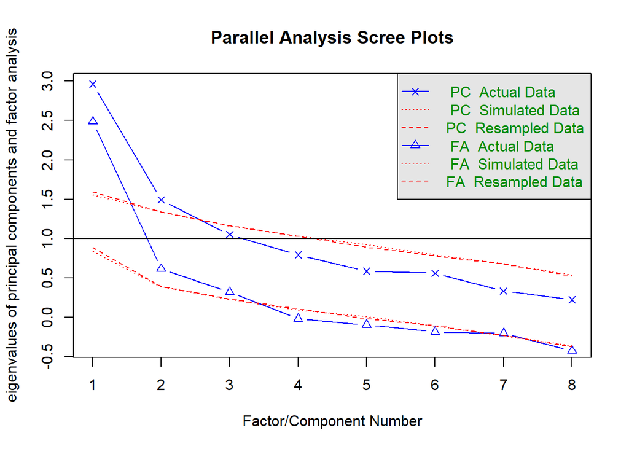

```
## Parallel analysis suggests that the number of factors =  2  and the number of components =  2
```

```r
fa.parallel(animal_data[,1:9][-1]) # See factor recommendation
```

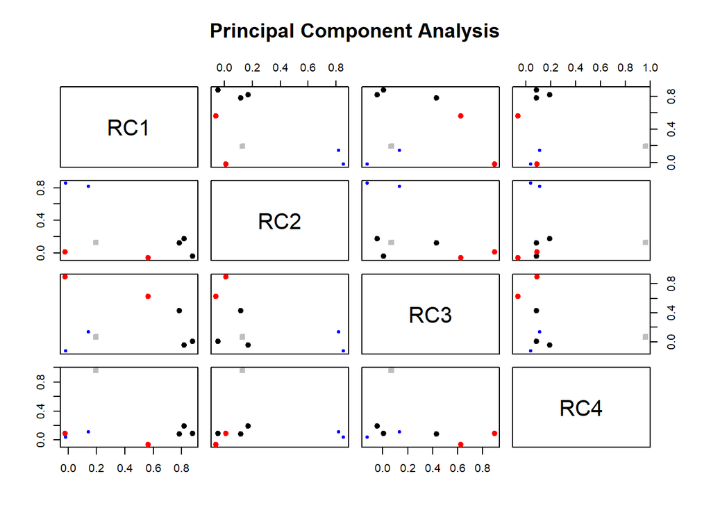

```r
fa.plot(fit.pc) # See Correlations within Factors
```

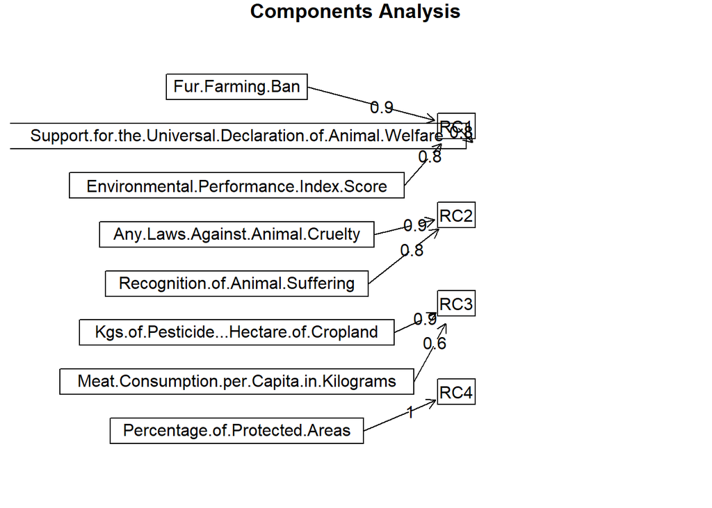

```r
fa.diagram(fit.pc) # Visualize the relationship
```

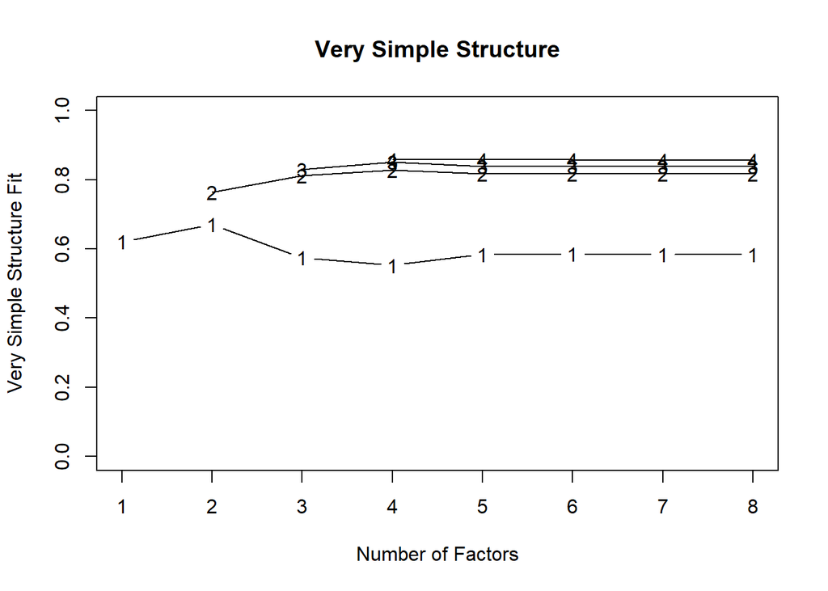

```
##
## Very Simple Structure
## Call: vss(x = animal_data[, 1:9][-1])
## VSS complexity 1 achieves a maximimum of 0.67  with  2  factors
## VSS complexity 2 achieves a maximimum of 0.83  with  4  factors
##
## The Velicer MAP achieves a minimum of 0.06  with  1  factors
## BIC achieves a minimum of  -42.85  with  1  factors
## Sample Size adjusted BIC achieves a minimum of  -5.11  with  3  factors
##
## Statistics by number of factors
##   vss1 vss2   map dof   chisq   prob sqresid  fit RMSEA   BIC SABIC complex
## 1 0.62 0.00 0.055  20 4.1e+01 0.0035     5.1 0.62 0.125 -42.9  20.1     1.0
## 2 0.67 0.76 0.073  13 2.1e+01 0.0774     3.2 0.76 0.093 -33.9   7.0     1.2
## 3 0.57 0.81 0.108   7 2.3e+00 0.9424     2.3 0.83 0.000 -27.1  -5.1     1.4
## 4 0.55 0.83 0.197   2 1.8e-01 0.9131     1.9 0.86 0.000  -8.2  -1.9     1.5
## 5 0.58 0.82 0.256  -2 6.2e-09     NA     1.9 0.86    NA    NA    NA     1.6
## 6 0.59 0.82 0.429  -5 2.6e-09     NA     1.9 0.86    NA    NA    NA     1.6
## 7 0.58 0.82 1.000  -7 8.7e-12     NA     1.9 0.86    NA    NA    NA     1.7
## 8 0.58 0.82    NA  -8 8.6e-12     NA     1.9 0.86    NA    NA    NA     1.7
##    eChisq    SRMR eCRMS  eBIC
## 1 5.0e+01 1.2e-01 0.137 -34.1
## 2 1.5e+01 6.3e-02 0.092 -39.9
## 3 1.0e+00 1.6e-02 0.033 -28.4
## 4 9.5e-02 5.0e-03 0.019  -8.3
## 5 2.4e-09 8.0e-07    NA    NA
## 6 6.3e-10 4.1e-07    NA    NA
## 7 3.1e-12 2.9e-08    NA    NA
## 8 3.1e-12 2.9e-08    NA    NA
```

```r
vss(animal_data[,1:9][-1]) # See Factor recommendations for a simple structure
```

INSIGHTS FOR EACH RCs :

-The first factor (RC1) comprises variables related to animal welfare policies, including fur farming bans, environmental performance index, and support for the universal declaration of animal welfare.

-The second factor (RC2) appears to be associated with legal aspects of animal rights, such as laws against animal cruelty and recognition of animal suffering.

-The third factor (RC3) seems to capture variables related to agricultural practices and environmental impact, including kilograms of pesticide on cropland and meat consumption.

-The fourth factor (RC4) seems to represent variables related to conservation efforts, specifically the percentage of protected areas. These factors provide a structured understanding of the underlying dimensions of animal rights across different countries.

Based on the variables included in each factor (RC), we can assign names that reflect the underlying dimensions they represent:

The names for the principal components (PCs) could be:

PC1: “Primary Dimension of Variation” PC2: “Secondary Dimension of Variation” PC3: “Tertiary Dimension of Variation”

These names reflect the order in which the principal components capture the variance in the dataset. They are named based on their relative importance in explaining the variability observed in the data. What would you name your principal components and factors? Why?

RC1: “Animal Welfare Policies”

RC2: “Legal Aspects of Animal Rights”

RC3: “Agricultural Practices and Environmental Impact”

RC4: “Conservation Efforts”

Percentage of Protected Areas

By examining the variables within each factor, we can identify common themes or patterns that reflect specific aspects of animal rights or related concepts. These names make it easier for researchers and stakeholders to understand and communicate the results of the factor analysis, facilitating discussions and decision-making processes related to animal welfare policies, legal aspects, agricultural practices, environmental impact, and conservation efforts.